# **Análisis geoestadístico con `geoR`**

Máster en Data Science & Business Analytics (con R Software)

José-María Montero (jose.mlorenzo@uclm.es)  
Gema Fernández-Avilés (gema.faviles@uclm.es)

01-03-2022

*Nota*:

Se autoriza expresamente el uso de este material a la Universidad de Castilla-La Mancha para la docencia del [Máster en Data Science & Business Analytics (con R Software)](https://blog.uclm.es/tp-mbsba/programa/).

### Profesores

### Material:

- Diapositivas básicas para llevar a cabo R de un análisis geoestadítico con la librería `geoR`
- Hoja de trucos con los pasos necesarios
- Videoclase explicativa del material proporcionado.

# Pasos de un análisis geoestadístico con `geoR`

#### Paso 1. Leemos los datos y preparamos el entormno. Creamos un objeto de la clase `as.geodata` (`geoR`)

#### Paso 2. ¿Existe algún tipo de dependencia espacial? Análisis exploratorio de datos espaciales.

#### Paso 3. ¿Cómo es la estructura de la dependencia espacial? Semivariograma empírico

#### Paso 4. ¿Es mi semivariograma válido? Ajuste del semivariograma empírico al semivariograma teórico.

#### Paso 5. ¿Puedo hacer predicciones en sitios donde no tenga datos de la variable que analizo? Kriging. Predicción y bondad de la predicción.

#### Paso 6. Evaluación y presentación de resultados. Valiación cruzada. Mapping.

# Pasos de un análisis geoestadístico con `geoR`. Ver cheatsheet

### Paso 1. Leemos los datos y convertimos a clase `geodata`

```r
library(geoR)
# `mygeodata` es un objeto espacial: $coords y $data
mygeodata <- as.geodata(mydata, coords.col = 1:2, data.col = 3)
```

```r
summary(mygeodata)
plot(mygeodata)
```

### Paso 3. Semivariograma empírico

```r
semivar_emp <- variog(mygeodata, max.dist = 2/3*distancia_maxima_coordenadas)
plot(semivar_emp)
```

### Paso 4. **Semivariograma teórico**

```r
semivar_teo <- eyefit(semivar_emp) # función interactiva
semivar_teo # contiene los parámetros del semivariograma teórico
    cov.model sigmasq  phi tausq kappa kappa2   practicalRange
```

```r
* `cov.model` = modelo de covarianza
* `sigmasq` = varianza parcial
* `phi` = rango o alcance
* `tausq` = nugget
* `practicalRange`= distancia en la que se estabiliza el semivariograma
```

### Paso 5. Kriging ordinario

```r
xx <- seq(min, max, l = 51)  #min y #máx para el eje x
yy <- seq(min, max, l = 51)  #min y #máx para el eje y
grid_prediccion <- expand.grid(x = xx, y = yy)

# help(krige.conv)
krig_ord <- krige.conv(mygeodata, #datos
                       loc = grid_prediccion, #grid de predicción
                       krige = krige.control(obj.m = semivar_teo) #semivariograma teórico
                       )
names(krig_ord)
```

### Paso 6. Evaluación y presentación de resultados. Mapping

```r
#varias funciones de mapeado
contour(krig_ord, filled = TRUE)
image(krig_ord, val = krig_ord$krige.var) #superficie de varianzas

# validación cruzada
mygeodata_xv <- xvalid(mygeodata, model = semivar_teo)
```

```r
library(plot3D)
# install.packages('plot3D')
persp3D(xx, yy, matrix(krig_ord$predict, nrow = length(xx)), theta=-60, phi=40)
```

# Caso de estudio: Interpolación del CO en Madrid mediante el kriging ordinario

Ejemplo tomado de **Montero, J. M., Fernández-Avilés, G., & Mateu, J. (2015). *Spatial and spatio-temporal geostatistical modeling and kriging* (Vol. 998). John Wiley & Sons.**

[figure not shown]

### Objetivo Predicción puntual del nivel de CO en la ciudad de Madrid

[interactive chart not shown]

### Paso 1. Leemos los datos y convertimos a clase `geodata`

```r
# lectura de geoR. Instalar si no lo tengo
library(geoR)

# lectura de los datos y coordenadas
data.co=read.table("data/Madrid_LOG_co50s10h.txt", header=TRUE)
MuniMadrid <- matrix(scan("data/MuniMadrid.txt"), ncol = 2, byrow = T)
estaciones <- read.table("data/coordata.txt", header = FALSE) # lo utilizo luego

# creación del objeto as.geodata()
head(data.co)
```

```
##          x       y        co
## 1 441301.4 4474964 0.9516579
## 2 440341.1 4474609 1.0152307
## 3 439591.1 4475156 0.9042182
## 4 439688.5 4481161 0.9001613
## 5 441401.3 4476644 1.1908876
## 6 442294.5 4475753 0.9202828
```

```r
co.50s.10h<-as.geodata(obj=data.co, coords.col = 1:2, data.col = 3)
```

### Paso 2. Análisis exploratorio de datos espaciales

```r
# descriptivos
summary(co.50s.10h)
```

```
## Number of data points: 23
##
## Coordinates summary
##            x       y
## min 436436.6 4470109
## max 448850.0 4481161
##
## Distance summary
##        min        max
##   820.6698 14355.1451
##
## Data summary
##       Min.    1st Qu.     Median       Mean    3rd Qu.       Max.
## 0.07696104 0.69303467 0.95165788 0.88895821 1.03302615 1.61541998
```

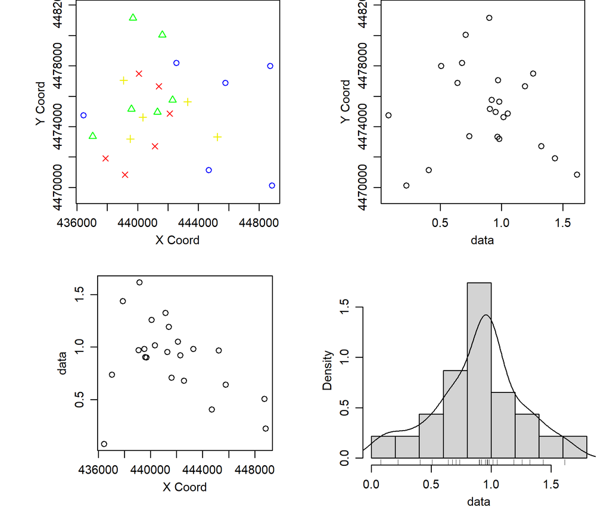

```r
# análisis gráfico
plot(co.50s.10h)
```

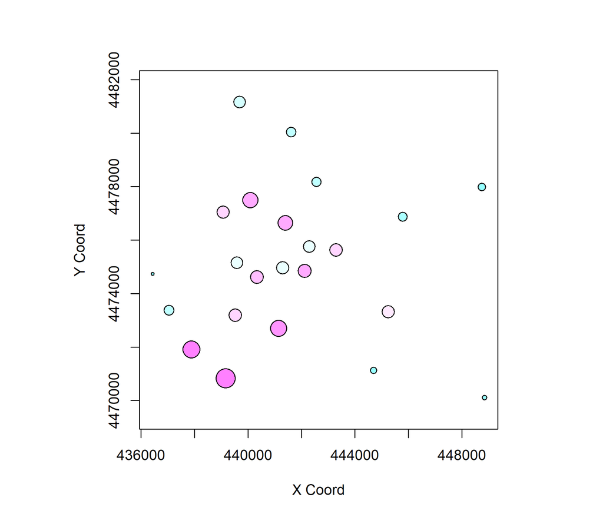

```r
# Mapa de quintiles
points(co.50s.10h, pch=21, bg=8, lwd=4, cex.max=3, col=cm.colors(12) )
```

### Paso 3. Cálculo del semivariogram empírico

#### `geoR::variog()`

```r
bin1.co.50s.10h <- variog(co.50s.10h, uvec = seq(800, 7000, l = 10), tolerance = pi/8)
```

```
## variog: computing omnidirectional variogram
```

```r
cloud.co.50s.10h <- variog(co.50s.10h, option = "cloud")
```

```
## variog: computing omnidirectional variogram
```

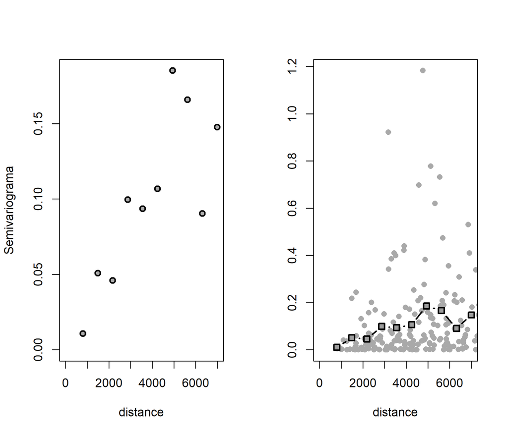

```r
par(mfrow = c(1, 2))
plot(bin1.co.50s.10h, ylab = "Semivariograma", main = "", col = 1, pch = 21, bg = "darkgray", lwd = 2)
plot(cloud.co.50s.10h, xlim = c(0, 7000), col = "darkgray", main = " ", pch = 16, ylab = " ")
lines(bin1.co.50s.10h, type = "b", pch = 22, bg = 8, lwd = 2, cex = 1.2, ylab = " ")
```

### Paso 4. Ajuste del semivariograma empírico a uno teoríco (spherical)

#### `geoR::eyefit()`

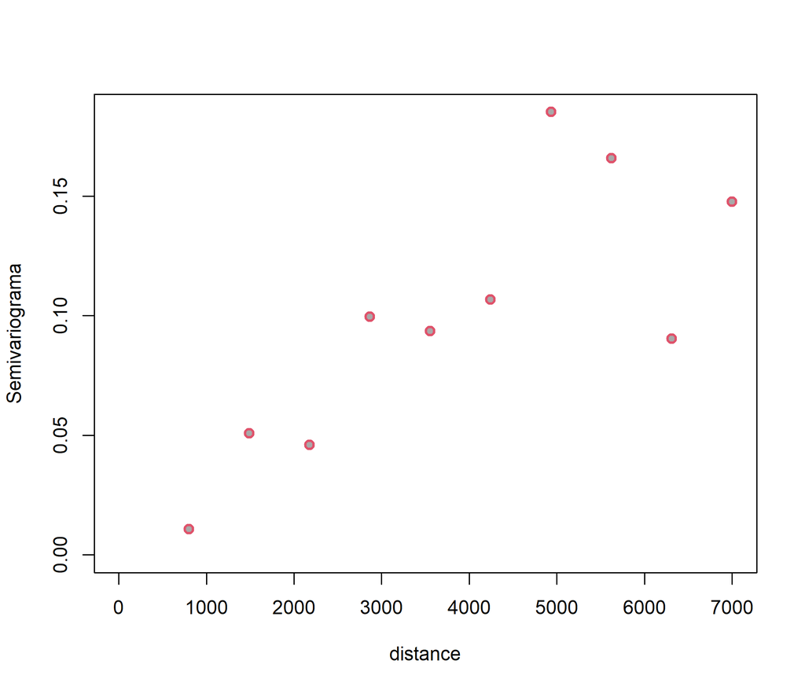

```r
# cuadro interactivo
plot(bin1.co.50s.10h, ylab = "Semivariograma", main = "", col = 2, pch = 21, bg = "darkgray", lwd = 2)
```

```r
#semivar_teo <- eyefit(bin1.co.50s.10h)
```

##### `geoR::variofit()` –> OLS, WLS

##### `geoR::likfit()` –> ME, REML

```r
ols <- variofit(bin1.co.50s.10h, ini = c(0.134, 1800), cov.model = "spherical",
    fix.nugget = FALSE, weights = "equal")
```

```
## variofit: covariance model used is spherical
## variofit: weights used: equal
## variofit: minimisation function used: optim
```

```r
ml <- likfit(co.50s.10h, coords = co.50s.10h$coords, data = co.50s.10h$data,
    cov.model = "spherical", ini = c(0.134, 1800), nugget = FALSE, fix.psiA = FALSE,
    fix.psiR = FALSE, lik.method = "ML")
```

[output not shown]

```r
wls <- variofit(bin1.co.50s.10h, ini = c(0.134, 1800), cov.model = "spherical",
    fix.nugget = FALSE, weights = "npairs")
```

```
## variofit: covariance model used is spherical
## variofit: weights used: npairs
## variofit: minimisation function used: optim
```

```r
reml <- likfit(co.50s.10h, coords = co.50s.10h$coords, data = co.50s.10h$data,
    cov.model = "spherical", ini = c(0.134, 1800), fix.psiA = FALSE, fix.psiR = FALSE,
    fix.nugget = FALSE, lik.method = "RML")
```

[output not shown]

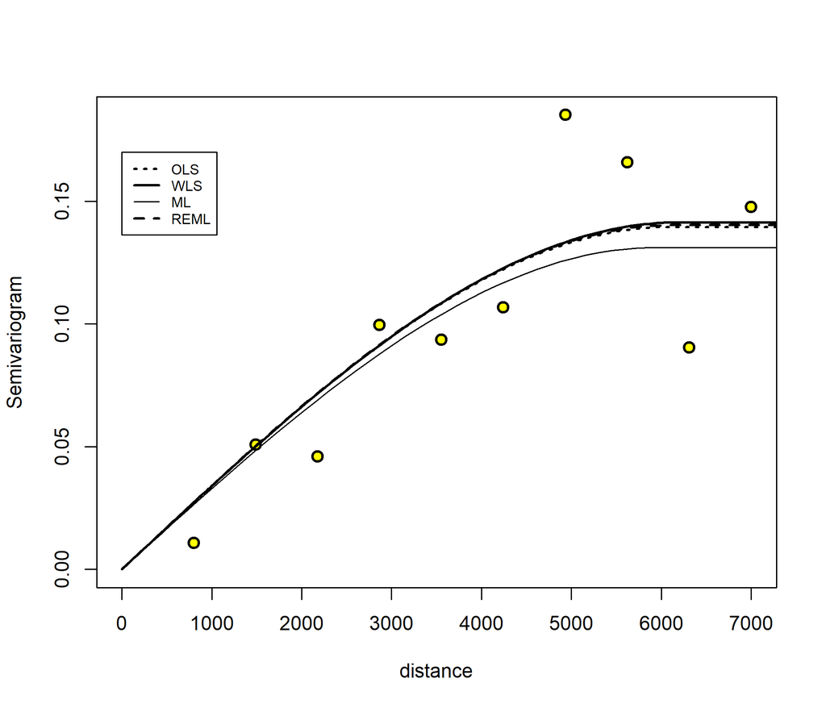

```r
# Representa ambos semivariogramas (empírico y teórico)

plot(bin1.co.50s.10h, ylab = "Semivariogram", main = " ",
     col = 1, pch = 21, bg = "yellow", lwd = 2, cex = 1.2)

lines(ols, lwd = 2, lty = 3);
lines(wls, lwd = 2, lty = 1);
lines(ml, lwd = 1, lty = 1);
lines(reml, lwd = 2, lty = 2)
legend(0.55, 0.17, legend = c("OLS", "WLS", "ML", "REML"),
       lty = c(3, 1, 1, 2), lwd = c(2, 2, 1, 2), cex = 0.7)
```

### Paso 5. Llevamos a cabo Kriging ordinario

##### geoR::krige.conv()

```r
# creamos una malla de interopolación
xx <- seq(min(MuniMadrid[, 1]), max(MuniMadrid[, 1]), l = 51)
yy <- seq(min(MuniMadrid[, 2]), max(MuniMadrid[, 2]), l = 51)

grid_prediccion <- expand.grid(xx, yy)


# Kriging ordinario
kc.co.2s.10h <- krige.conv(co.50s.10h,
                           coords = co.50s.10h$coords,
                           data = co.50s.10h$data,
                           loc = grid_prediccion,
                           #Opición 1: especificamos todos los parámetros del semivariorama
                           krige = krige.control(cov.model = "spherical",
                                                 cov.pars = c(0.1403, 6096.4841),
                                                 nugget = 0)
                           # Opición 2: especificamos el semivariograma
                           #krige = krige.control(obj.m = semivar_teo) #semivariograma teórico
                           )
```

```
## krige.conv: model with constant mean
## krige.conv: Kriging performed using global neighbourhood
```

```r
str(kc.co.2s.10h)
```

```
## List of 6
##  $ predict     : num [1:2601] 0.738 0.738 0.738 0.738 0.738 ...
##  $ krige.var   : num [1:2601] 0.159 0.159 0.159 0.159 0.159 ...
##  $ beta.est    : Named num 0.738
##   ..- attr(*, "names")= chr "beta"
##  $ distribution: chr "normal"
##  $ message     : chr "krige.conv: Kriging performed using global neighbourhood"
##  $ call        : language krige.conv(geodata = co.50s.10h, coords = co.50s.10h$coords, data = co.50s.10h$data,      locations = grid_predic| __truncated__ ...
##  - attr(*, "sp.dim")= chr "2d"
##  - attr(*, "prediction.locations")= symbol grid_prediccion
##  - attr(*, "parent.env")=<environment: R_GlobalEnv>
##  - attr(*, "data.locations")= language co.50s.10h$coords
##  - attr(*, "class")= chr "kriging"
```

### Paso 6. Evaluación y presentación de resultados. Mapping

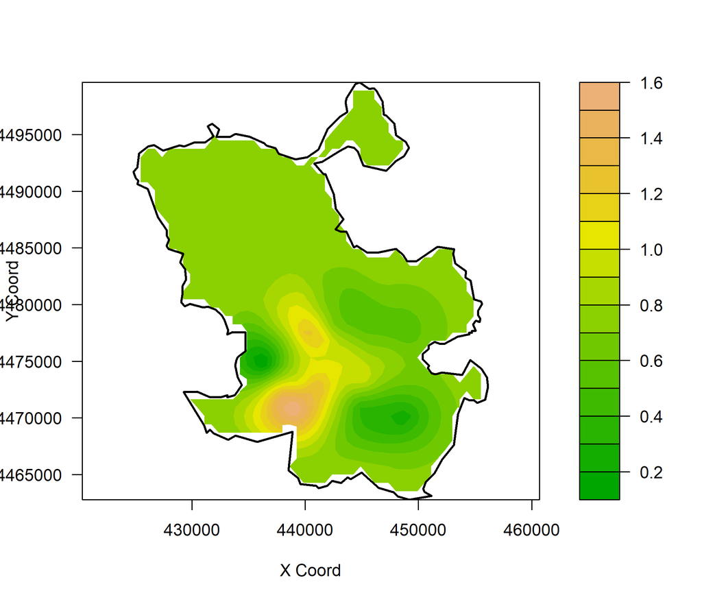

```r
# prediction map
contour(kc.co.2s.10h,  borders = MuniMadrid, filled=TRUE, cex=1, col=terrain.colors(20))
```

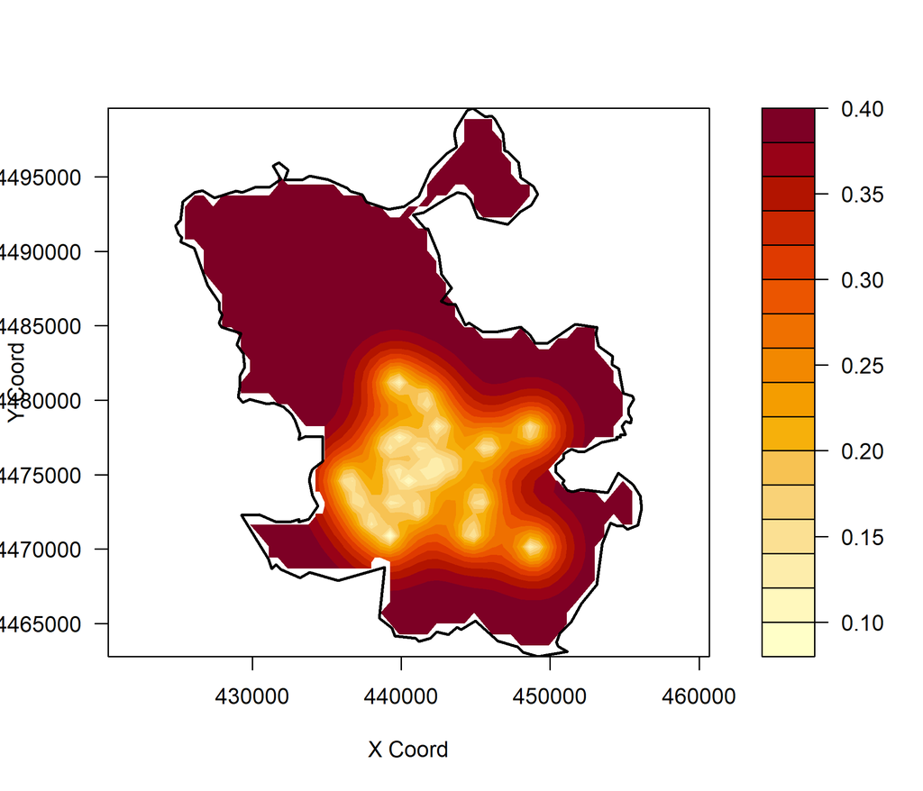

```r
# sd map
contour(kc.co.2s.10h,  values = sqrt(kc.co.2s.10h$krige.var),
        borders = MuniMadrid, filled=TRUE)
```

### Paso 6. Avanzado

[interactive chart not shown]

# Librerías R utilizadas

Cheng, J., Karambelkar, B. and Xie, Y. (2021). leaflet: Create Interactive Web Maps with the JavaScript ‘Leaflet’ Library. R package version 2.0.4.1. https://CRAN.R-project.org/package=leaflet

Hernangómez, D. (2021). mapSpain: Administrative Boundaries of Spain. R package version 0.2.3. http://doi.org/10.5281/zenodo.4318024. Package url: https://CRAN.R-project.org/package=mapSpain

Ribeiro, P., Diggle, P., Schlather, M., Bivand, R. and Ripley, R. (2020). geoR: Analysis of Geostatistical Data. R package version 1.8-1. https://CRAN.R-project.org/package=geoR